# Quiz - Lesson 7

Duncan Munslow

August 11, 2018

# For Questions 1-5, consider the example of flipping a coin with unknown probability of heads ():

### Question 2

Coin flip:

Which of the following graphs depicts the posterior PDF of theta if we observe the sequence (T, T, T, T)? (You may want to use R or Excel to plot the posterior.)

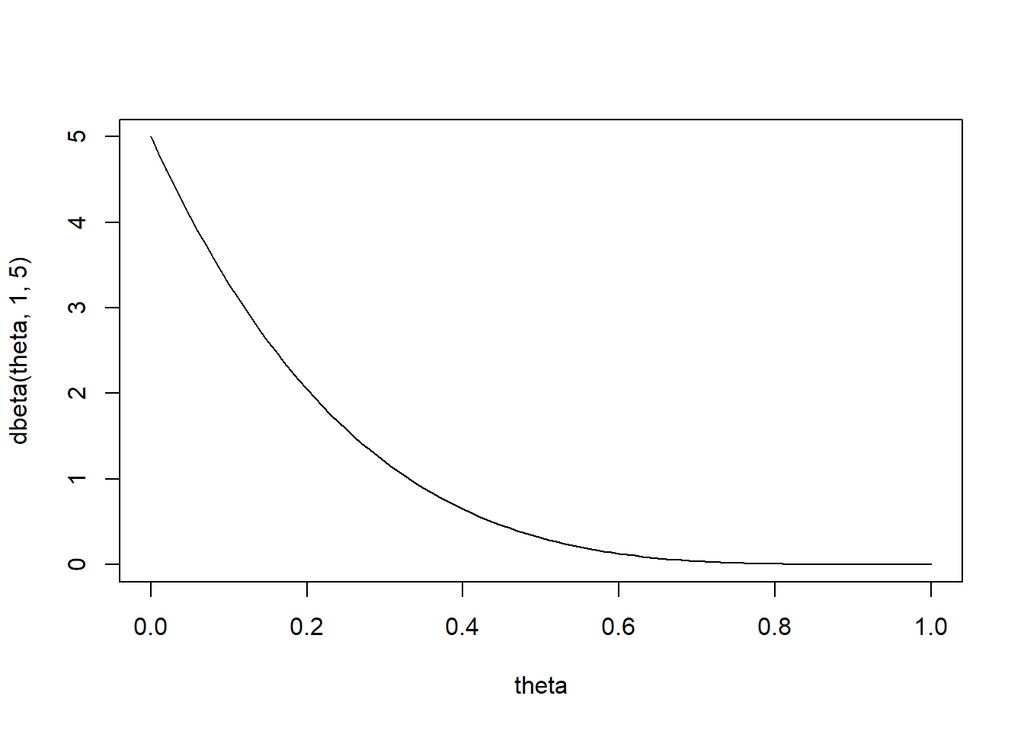

## Question 3

What is the maximum likelihood estimate (MLE) of theta if we observe the sequence (T, T, T, T)?

#### Answer: 0/4 = 0

## Question 4

What is the posterior mean estimate of theta if we observe the sequence (T, T, T, T)? Round your answer to two decimal places.

Note: Mean of Beta(alpa, beta) = Alpha / Alpha + Beta

```r
1/6
```

```
## [1] 0.1666667
```

## Question 5

Use R or Excel to find the posterior probability that theta <0.5 if we observe the sequence (T,T,T,T). Round your answer to two decimal places.

```r
pbeta(.5,1,5)
```

```
## [1] 0.96875
```

For Questions 6-9, consider the following scenario:

An engineer wants to assess the reliability of a new chemical refinement process by measuring theta, the proportion of samples that fail a battery of tests. These tests are expensive, and the budget only allows 20 tests on randomly selected samples. Assuming each test is independent, she assigns a binomial likelihood where XX counts the samples which fail. Historically, new processes pass about half of the time, so she assigns a Beta(2,2) prior for theta (prior mean 0.5 and prior sample size 4). The outcome of the tests is 6 fails and 14 passes.

## Question 6

What is the posterior distribution for theta?

#### Answer: Beta(2 + 6, 2+20-6) = Beta( 8, 16)

## Question 7

Use R or Excel to calculate the upper end of an equal-tailed 95% credible interval for theta. Round your answer to two decimal places.

```r
qbeta(.975,8,16)
```

```
## [1] 0.5291917
```

```r
# Question 8
qbeta(.025,8,16) > .3
```

```
## [1] FALSE
```

## Question 8

The engineer tells you that the process is considered promising and can proceed to another phase of testing if we are 90% sure that the failure rate is less than .35.

Calculate the posterior probability P(theta <.35∣x). In your role as the statistician, would you say that this new chemical should pass?

```r
pbeta(.35,8,16)
```

```
## [1] 0.586431
```